#### Jon Krenick Z23674518

#### Sydney Durrance Z23601407

```python
import pandas as pd
import numpy as np
import matplotlib
import matplotlib.pyplot as plt
import seaborn as sns
```

# Data Wrangling

In the section of the notebook we:

- Load in the dataset
- Change variable data types
- Check for missing values
- Check for duplicate values
- Rename existing columns
- Engineer multiple new variables for analysis
- Created two smaller data frames based on a condition

```python
# Set global options to allow us to view all of dataframe
pd.set_option('display.max_columns', None)
pd.set_option('display.width', None)

# REFERENCE
# https://pandas.pydata.org/docs/reference/api/pandas.set_option.html
```

```python
# Read in dataframe
df = pd.read_csv('../Data/diabetes_binary_health_indicators_BRFSS2015.csv')

# Display first 5 rows
df.head()
```

|  | Diabetes_binary | HighBP | HighChol | CholCheck | BMI | Smoker | Stroke | HeartDiseaseorAttack | PhysActivity | Fruits | Veggies | HvyAlcoholConsump | AnyHealthcare | NoDocbcCost | GenHlth | MentHlth | PhysHlth | DiffWalk | Sex | Age | Education | Income |
| --- | --- | --- | --- | --- | --- | --- | --- | --- | --- | --- | --- | --- | --- | --- | --- | --- | --- | --- | --- | --- | --- | --- |
| 0 | 0.0 | 1.0 | 1.0 | 1.0 | 40.0 | 1.0 | 0.0 | 0.0 | 0.0 | 0.0 | 1.0 | 0.0 | 1.0 | 0.0 | 5.0 | 18.0 | 15.0 | 1.0 | 0.0 | 9.0 | 4.0 | 3.0 |
| 1 | 0.0 | 0.0 | 0.0 | 0.0 | 25.0 | 1.0 | 0.0 | 0.0 | 1.0 | 0.0 | 0.0 | 0.0 | 0.0 | 1.0 | 3.0 | 0.0 | 0.0 | 0.0 | 0.0 | 7.0 | 6.0 | 1.0 |
| 2 | 0.0 | 1.0 | 1.0 | 1.0 | 28.0 | 0.0 | 0.0 | 0.0 | 0.0 | 1.0 | 0.0 | 0.0 | 1.0 | 1.0 | 5.0 | 30.0 | 30.0 | 1.0 | 0.0 | 9.0 | 4.0 | 8.0 |
| 3 | 0.0 | 1.0 | 0.0 | 1.0 | 27.0 | 0.0 | 0.0 | 0.0 | 1.0 | 1.0 | 1.0 | 0.0 | 1.0 | 0.0 | 2.0 | 0.0 | 0.0 | 0.0 | 0.0 | 11.0 | 3.0 | 6.0 |
| 4 | 0.0 | 1.0 | 1.0 | 1.0 | 24.0 | 0.0 | 0.0 | 0.0 | 1.0 | 1.0 | 1.0 | 0.0 | 1.0 | 0.0 | 2.0 | 3.0 | 0.0 | 0.0 | 0.0 | 11.0 | 5.0 | 4.0 |

```python
# View summary statistics of the data
df.describe()
```

|  | Diabetes_binary | HighBP | HighChol | CholCheck | BMI | Smoker | Stroke | HeartDiseaseorAttack | PhysActivity | Fruits | Veggies | HvyAlcoholConsump | AnyHealthcare | NoDocbcCost | GenHlth | MentHlth | PhysHlth | DiffWalk | Sex | Age | Education | Income |
| --- | --- | --- | --- | --- | --- | --- | --- | --- | --- | --- | --- | --- | --- | --- | --- | --- | --- | --- | --- | --- | --- | --- |
| count | 253680.000000 | 253680.000000 | 253680.000000 | 253680.000000 | 253680.000000 | 253680.000000 | 253680.000000 | 253680.000000 | 253680.000000 | 253680.000000 | 253680.000000 | 253680.000000 | 253680.000000 | 253680.000000 | 253680.000000 | 253680.000000 | 253680.000000 | 253680.000000 | 253680.000000 | 253680.000000 | 253680.000000 | 253680.000000 |
| mean | 0.139333 | 0.429001 | 0.424121 | 0.962670 | 28.382364 | 0.443169 | 0.040571 | 0.094186 | 0.756544 | 0.634256 | 0.811420 | 0.056197 | 0.951053 | 0.084177 | 2.511392 | 3.184772 | 4.242081 | 0.168224 | 0.440342 | 8.032119 | 5.050434 | 6.053875 |
| std | 0.346294 | 0.494934 | 0.494210 | 0.189571 | 6.608694 | 0.496761 | 0.197294 | 0.292087 | 0.429169 | 0.481639 | 0.391175 | 0.230302 | 0.215759 | 0.277654 | 1.068477 | 7.412847 | 8.717951 | 0.374066 | 0.496429 | 3.054220 | 0.985774 | 2.071148 |
| min | 0.000000 | 0.000000 | 0.000000 | 0.000000 | 12.000000 | 0.000000 | 0.000000 | 0.000000 | 0.000000 | 0.000000 | 0.000000 | 0.000000 | 0.000000 | 0.000000 | 1.000000 | 0.000000 | 0.000000 | 0.000000 | 0.000000 | 1.000000 | 1.000000 | 1.000000 |
| 25% | 0.000000 | 0.000000 | 0.000000 | 1.000000 | 24.000000 | 0.000000 | 0.000000 | 0.000000 | 1.000000 | 0.000000 | 1.000000 | 0.000000 | 1.000000 | 0.000000 | 2.000000 | 0.000000 | 0.000000 | 0.000000 | 0.000000 | 6.000000 | 4.000000 | 5.000000 |
| 50% | 0.000000 | 0.000000 | 0.000000 | 1.000000 | 27.000000 | 0.000000 | 0.000000 | 0.000000 | 1.000000 | 1.000000 | 1.000000 | 0.000000 | 1.000000 | 0.000000 | 2.000000 | 0.000000 | 0.000000 | 0.000000 | 0.000000 | 8.000000 | 5.000000 | 7.000000 |
| 75% | 0.000000 | 1.000000 | 1.000000 | 1.000000 | 31.000000 | 1.000000 | 0.000000 | 0.000000 | 1.000000 | 1.000000 | 1.000000 | 0.000000 | 1.000000 | 0.000000 | 3.000000 | 2.000000 | 3.000000 | 0.000000 | 1.000000 | 10.000000 | 6.000000 | 8.000000 |
| max | 1.000000 | 1.000000 | 1.000000 | 1.000000 | 98.000000 | 1.000000 | 1.000000 | 1.000000 | 1.000000 | 1.000000 | 1.000000 | 1.000000 | 1.000000 | 1.000000 | 5.000000 | 30.000000 | 30.000000 | 1.000000 | 1.000000 | 13.000000 | 6.000000 | 8.000000 |

```python
# View the default datatypes for each of the variables
df.info(memory_usage = 'deep')
```

```
<class 'pandas.DataFrame'>
RangeIndex: 253680 entries, 0 to 253679
Data columns (total 22 columns):
 #   Column                Non-Null Count   Dtype
---  ------                --------------   -----
 0   Diabetes_binary       253680 non-null  float64
 1   HighBP                253680 non-null  float64
 2   HighChol              253680 non-null  float64
 3   CholCheck             253680 non-null  float64
 4   BMI                   253680 non-null  float64
 5   Smoker                253680 non-null  float64
 6   Stroke                253680 non-null  float64
 7   HeartDiseaseorAttack  253680 non-null  float64
 8   PhysActivity          253680 non-null  float64
 9   Fruits                253680 non-null  float64
 10  Veggies               253680 non-null  float64
 11  HvyAlcoholConsump     253680 non-null  float64
 12  AnyHealthcare         253680 non-null  float64
 13  NoDocbcCost           253680 non-null  float64
 14  GenHlth               253680 non-null  float64
 15  MentHlth              253680 non-null  float64
 16  PhysHlth              253680 non-null  float64
 17  DiffWalk              253680 non-null  float64
 18  Sex                   253680 non-null  float64
 19  Age                   253680 non-null  float64
 20  Education             253680 non-null  float64
 21  Income                253680 non-null  float64
dtypes: float64(22)
memory usage: 42.6 MB
```

#### Convert Datatypes to decrease memory usage

```python
# Downcast variable types to save on memory
df = (
        df.astype({
            'Diabetes_binary' : 'int8',
            'HighBP' : 'int8',
            'HighChol' : 'int8',
            'CholCheck' : 'int8',
            'BMI' : 'float32',
            'Smoker' : 'int8',
            'Stroke' : 'int8',
            'HeartDiseaseorAttack' : 'int8',
            'PhysActivity' : 'int8',
            'Fruits' : 'int8',
            'Veggies' : 'int8',
            'HvyAlcoholConsump' : 'int8',
            'AnyHealthcare' : 'int8',
            'NoDocbcCost' : 'int8',
            'GenHlth' : 'int8',
            'MentHlth' : 'int8',
            'PhysHlth' : 'int8',
            'DiffWalk' : 'int8',
            'Sex' : 'int8',
            'Age' : 'int8',
            'Education' : 'int8',
            'Income' : 'int8'
        })
)

df.head()
```

|  | Diabetes_binary | HighBP | HighChol | CholCheck | BMI | Smoker | Stroke | HeartDiseaseorAttack | PhysActivity | Fruits | Veggies | HvyAlcoholConsump | AnyHealthcare | NoDocbcCost | GenHlth | MentHlth | PhysHlth | DiffWalk | Sex | Age | Education | Income |
| --- | --- | --- | --- | --- | --- | --- | --- | --- | --- | --- | --- | --- | --- | --- | --- | --- | --- | --- | --- | --- | --- | --- |
| 0 | 0 | 1 | 1 | 1 | 40.0 | 1 | 0 | 0 | 0 | 0 | 1 | 0 | 1 | 0 | 5 | 18 | 15 | 1 | 0 | 9 | 4 | 3 |
| 1 | 0 | 0 | 0 | 0 | 25.0 | 1 | 0 | 0 | 1 | 0 | 0 | 0 | 0 | 1 | 3 | 0 | 0 | 0 | 0 | 7 | 6 | 1 |
| 2 | 0 | 1 | 1 | 1 | 28.0 | 0 | 0 | 0 | 0 | 1 | 0 | 0 | 1 | 1 | 5 | 30 | 30 | 1 | 0 | 9 | 4 | 8 |
| 3 | 0 | 1 | 0 | 1 | 27.0 | 0 | 0 | 0 | 1 | 1 | 1 | 0 | 1 | 0 | 2 | 0 | 0 | 0 | 0 | 11 | 3 | 6 |
| 4 | 0 | 1 | 1 | 1 | 24.0 | 0 | 0 | 0 | 1 | 1 | 1 | 0 | 1 | 0 | 2 | 3 | 0 | 0 | 0 | 11 | 5 | 4 |

```python
# View the new memory usage - decreased memory from 42.6 MB down to 6.0 MB
df.info(memory_usage = 'deep')
```

```
<class 'pandas.DataFrame'>
RangeIndex: 253680 entries, 0 to 253679
Data columns (total 22 columns):
 #   Column                Non-Null Count   Dtype
---  ------                --------------   -----
 0   Diabetes_binary       253680 non-null  int8
 1   HighBP                253680 non-null  int8
 2   HighChol              253680 non-null  int8
 3   CholCheck             253680 non-null  int8
 4   BMI                   253680 non-null  float32
 5   Smoker                253680 non-null  int8
 6   Stroke                253680 non-null  int8
 7   HeartDiseaseorAttack  253680 non-null  int8
 8   PhysActivity          253680 non-null  int8
 9   Fruits                253680 non-null  int8
 10  Veggies               253680 non-null  int8
 11  HvyAlcoholConsump     253680 non-null  int8
 12  AnyHealthcare         253680 non-null  int8
 13  NoDocbcCost           253680 non-null  int8
 14  GenHlth               253680 non-null  int8
 15  MentHlth              253680 non-null  int8
 16  PhysHlth              253680 non-null  int8
 17  DiffWalk              253680 non-null  int8
 18  Sex                   253680 non-null  int8
 19  Age                   253680 non-null  int8
 20  Education             253680 non-null  int8
 21  Income                253680 non-null  int8
dtypes: float32(1), int8(21)
memory usage: 6.0 MB
```

#### Check for missing values and duplicates

- As we can see there are no missing values in this dataset
- There were 24,206 duplicated rows in the dataset, so we dropped them

```python
# Check for missing values
df.isna().sum()
```

```
Diabetes_binary         0
HighBP                  0
HighChol                0
CholCheck               0
BMI                     0
Smoker                  0
Stroke                  0
HeartDiseaseorAttack    0
PhysActivity            0
Fruits                  0
Veggies                 0
HvyAlcoholConsump       0
AnyHealthcare           0
NoDocbcCost             0
GenHlth                 0
MentHlth                0
PhysHlth                0
DiffWalk                0
Sex                     0
Age                     0
Education               0
Income                  0
dtype: int64
```

```python
# Check for duplicates
df.duplicated().sum()
```

```
np.int64(24206)
```

```python
# Drop duplicates
df = df.drop_duplicates().reset_index(drop = True)

# View df
df.head()
```

|  | Diabetes_binary | HighBP | HighChol | CholCheck | BMI | Smoker | Stroke | HeartDiseaseorAttack | PhysActivity | Fruits | Veggies | HvyAlcoholConsump | AnyHealthcare | NoDocbcCost | GenHlth | MentHlth | PhysHlth | DiffWalk | Sex | Age | Education | Income |
| --- | --- | --- | --- | --- | --- | --- | --- | --- | --- | --- | --- | --- | --- | --- | --- | --- | --- | --- | --- | --- | --- | --- |
| 0 | 0 | 1 | 1 | 1 | 40.0 | 1 | 0 | 0 | 0 | 0 | 1 | 0 | 1 | 0 | 5 | 18 | 15 | 1 | 0 | 9 | 4 | 3 |
| 1 | 0 | 0 | 0 | 0 | 25.0 | 1 | 0 | 0 | 1 | 0 | 0 | 0 | 0 | 1 | 3 | 0 | 0 | 0 | 0 | 7 | 6 | 1 |
| 2 | 0 | 1 | 1 | 1 | 28.0 | 0 | 0 | 0 | 0 | 1 | 0 | 0 | 1 | 1 | 5 | 30 | 30 | 1 | 0 | 9 | 4 | 8 |
| 3 | 0 | 1 | 0 | 1 | 27.0 | 0 | 0 | 0 | 1 | 1 | 1 | 0 | 1 | 0 | 2 | 0 | 0 | 0 | 0 | 11 | 3 | 6 |
| 4 | 0 | 1 | 1 | 1 | 24.0 | 0 | 0 | 0 | 1 | 1 | 1 | 0 | 1 | 0 | 2 | 3 | 0 | 0 | 0 | 11 | 5 | 4 |

```python
# Ensure all duplicates were dropped
df.duplicated().sum()
```

```
np.int64(0)
```

#### Rename Columns for readability

```python
# View current columns
df.columns
```

```
Index(['Diabetes_binary', 'HighBP', 'HighChol', 'CholCheck', 'BMI', 'Smoker',
       'Stroke', 'HeartDiseaseorAttack', 'PhysActivity', 'Fruits', 'Veggies',
       'HvyAlcoholConsump', 'AnyHealthcare', 'NoDocbcCost', 'GenHlth',
       'MentHlth', 'PhysHlth', 'DiffWalk', 'Sex', 'Age', 'Education',
       'Income'],
      dtype='str')
```

```python
# Rename columns
df = df.rename(columns= {
    'Diabetes_binary' : 'Diabetes',
    'HighBP' : 'HighBloodPressure',
    'HighChol' : 'HighCholesterol',
    'CholCheck' : 'CholesterolCheck',
    'HeartDiseaseorAttack' : 'HeartDiseaseOrAttack',
    'PhysActivity' : 'PhysicalActivity',
    'Fruits' : 'EatsFruitsDaily',
    'Veggies' : 'EatsVegetablesDaily',
    'HvyAlcoholConsump' : 'HeavyAlcoholConsumption',
    'AnyHealthcare' : 'HasHealthCareCoverage',
    'NoDocbcCost' : 'NoDoctorDueToCost',
    'GenHlth' : 'GeneralHealth',
    'MentHlth' : 'MentalHealthDays',
    'PhysHlth' : 'PhysicalHealthDays',
    'DiffWalk' : 'DifficultyWalking'
})

# View new df
df.head()
```

|  | Diabetes | HighBloodPressure | HighCholesterol | CholesterolCheck | BMI | Smoker | Stroke | HeartDiseaseOrAttack | PhysicalActivity | EatsFruitsDaily | EatsVegetablesDaily | HeavyAlcoholConsumption | HasHealthCareCoverage | NoDoctorDueToCost | GeneralHealth | MentalHealthDays | PhysicalHealthDays | DifficultyWalking | Sex | Age | Education | Income |
| --- | --- | --- | --- | --- | --- | --- | --- | --- | --- | --- | --- | --- | --- | --- | --- | --- | --- | --- | --- | --- | --- | --- |
| 0 | 0 | 1 | 1 | 1 | 40.0 | 1 | 0 | 0 | 0 | 0 | 1 | 0 | 1 | 0 | 5 | 18 | 15 | 1 | 0 | 9 | 4 | 3 |
| 1 | 0 | 0 | 0 | 0 | 25.0 | 1 | 0 | 0 | 1 | 0 | 0 | 0 | 0 | 1 | 3 | 0 | 0 | 0 | 0 | 7 | 6 | 1 |
| 2 | 0 | 1 | 1 | 1 | 28.0 | 0 | 0 | 0 | 0 | 1 | 0 | 0 | 1 | 1 | 5 | 30 | 30 | 1 | 0 | 9 | 4 | 8 |
| 3 | 0 | 1 | 0 | 1 | 27.0 | 0 | 0 | 0 | 1 | 1 | 1 | 0 | 1 | 0 | 2 | 0 | 0 | 0 | 0 | 11 | 3 | 6 |
| 4 | 0 | 1 | 1 | 1 | 24.0 | 0 | 0 | 0 | 1 | 1 | 1 | 0 | 1 | 0 | 2 | 3 | 0 | 0 | 0 | 11 | 5 | 4 |

#### Create New Features for Analysis

```python
# Convert the GeneralHealth column integer values into readable categories
df['GeneralHealthGroup'] = (
    pd.Categorical(
        df.loc[:, 'GeneralHealth']
        .map({
            1 : 'Excellent',
            2 : 'Very Good',
            3 : 'Good',
            4 : 'Fair',
            5 : 'Poor'
        }),
        categories = [
            'Excellent', 'Very Good', 'Good', 'Fair', 'Poor'
        ],
        ordered = True
    )
)

# Create bins of days based on the MentalHealthDays column
df['MentalHealthDaysGroup'] = (
    pd.cut(
        df.loc[:, 'MentalHealthDays'],
        bins = [-1, 0, 13, 30],
        labels = ['No Days', 'Some Days', 'Frequent Days']
    )
)

# Create bins of days based on the PhysicalHealthDays column
df['PhysicalHealthDaysGroup'] = (
    pd.cut(
        df.loc[:, 'PhysicalHealthDays'],
        bins = [-1, 0, 13, 30],
        labels = ['No Days', 'Some Days', 'Frequent Days']
    )
)

# Create proper bins for BMI values using the CDC categories:
# REFERENCE: https://www.cdc.gov/bmi/adult-calculator/bmi-categories.html
df['BMIGroup'] = (
    pd.cut(
        df.loc[:, 'BMI'],
        bins = [0, 18.5, 25, 30, 35, 40, np.inf],
        labels = [
            'Underweight', 'Healthy Weight', 'Overweight',
            'Class 1 Obesity', 'Class 2 Obesity', 'Class 3 Obesity'
        ],
        right = False
    )
)

# Convert binary sex label into a readable category
df['SexLabel'] = (
    pd.Categorical(
        df.loc[:, 'Sex']
        .map({
            0 : 'Female',
            1 : 'Male'
        }),
        categories = ['Female', 'Male'],
        ordered = False
    )
)

# Convert the messy age group integers into proper readable labels
df['AgeGroup'] = (
    pd.Categorical(
        df.loc[:, 'Age']
        .map({
            1 : '18-24',
            2 : '25-29',
            3 : '30-34',
            4 : '35-39',
            5 : '40-44',
            6 : '45-49',
            7 : '50-54',
            8 : '55-59',
            9 : '60-64',
            10 : '65-69',
            11 : '70-74',
            12 : '75-79',
            13 : '80+'
        }),
        categories = [
            '18-24', '25-29', '30-34', '35-39', '40-44', '45-49', '50-54',
            '55-59', '60-64', '65-69', '70-74', '75-79', '80+'
        ],
        ordered = True
    )
)

# Convert the messy education level integers into proper readable labels
df['EducationGroup'] = (
    pd.Categorical(
        df.loc[:, 'Education']
        .map({
            1 : 'Never Attended School or Kindergarten Only',
            2 : 'Completed Grades 1 through 8',
            3 : 'Completed Grades 9 through 11',
            4 : 'High School Graduate or GED',
            5 : 'Some College or Technical School',
            6 : 'College Graduate'
        }),
        categories = [
            'Never Attended School or Kindergarten Only',
            'Completed Grades 1 through 8',
            'Completed Grades 9 through 11',
            'High School Graduate or GED',
            'Some College or Technical School',
            'College Graduate'
        ],
        ordered = True
    )
)

# # Convert the messy income bracket integers into proper readable labels
df['IncomeGroup'] = (
    pd.Categorical(
        df.loc[:, 'Income']
        .map({
            1 : 'Less than $10,000',
            2 : '$10,000 to <$15,000',
            3 : '$15,000 to <$20,000',
            4 : '$20,000 to <$25,000',
            5 : '$25,000 to <$35,000',
            6 : '$35,000 to <$50,000',
            7 : '$50,000 to <$75,000',
            8 : '$75,000+'
        }),
        categories = [
            'Less than $10,000', '$10,000 to <$15,000', '$15,000 to <$20,000', '$20,000 to <$25,000',
            '$25,000 to <$35,000', '$35,000 to <$50,000', '$50,000 to <$75,000', '$75,000+'
        ],
        ordered = True
    )
)

# View the new df
df.head()
```

|  | Diabetes | HighBloodPressure | HighCholesterol | CholesterolCheck | BMI | Smoker | Stroke | HeartDiseaseOrAttack | PhysicalActivity | EatsFruitsDaily | EatsVegetablesDaily | HeavyAlcoholConsumption | HasHealthCareCoverage | NoDoctorDueToCost | GeneralHealth | MentalHealthDays | PhysicalHealthDays | DifficultyWalking | Sex | Age | Education | Income | GeneralHealthGroup | MentalHealthDaysGroup | PhysicalHealthDaysGroup | BMIGroup | SexLabel | AgeGroup | EducationGroup | … |
| --- | --- | --- | --- | --- | --- | --- | --- | --- | --- | --- | --- | --- | --- | --- | --- | --- | --- | --- | --- | --- | --- | --- | --- | --- | --- | --- | --- | --- | --- | --- |
| 0 | 0 | 1 | 1 | 1 | 40.0 | 1 | 0 | 0 | 0 | 0 | 1 | 0 | 1 | 0 | 5 | 18 | 15 | 1 | 0 | 9 | 4 | 3 | Poor | Frequent Days | Frequent Days | Class 3 Obesity | Female | 60-64 | High School Graduate or GED | … |
| 1 | 0 | 0 | 0 | 0 | 25.0 | 1 | 0 | 0 | 1 | 0 | 0 | 0 | 0 | 1 | 3 | 0 | 0 | 0 | 0 | 7 | 6 | 1 | Good | No Days | No Days | Overweight | Female | 50-54 | College Graduate | … |
| 2 | 0 | 1 | 1 | 1 | 28.0 | 0 | 0 | 0 | 0 | 1 | 0 | 0 | 1 | 1 | 5 | 30 | 30 | 1 | 0 | 9 | 4 | 8 | Poor | Frequent Days | Frequent Days | Overweight | Female | 60-64 | High School Graduate or GED | … |
| 3 | 0 | 1 | 0 | 1 | 27.0 | 0 | 0 | 0 | 1 | 1 | 1 | 0 | 1 | 0 | 2 | 0 | 0 | 0 | 0 | 11 | 3 | 6 | Very Good | No Days | No Days | Overweight | Female | 70-74 | Completed Grades 9 through 11 | … |
| 4 | 0 | 1 | 1 | 1 | 24.0 | 0 | 0 | 0 | 1 | 1 | 1 | 0 | 1 | 0 | 2 | 3 | 0 | 0 | 0 | 11 | 5 | 4 | Very Good | Some Days | No Days | Healthy Weight | Female | 70-74 | Some College or Technical School | … |

```python
# Check to ensure all new variables are categorical type
df.info(memory_usage = 'deep')
```

```
<class 'pandas.DataFrame'>
RangeIndex: 229474 entries, 0 to 229473
Data columns (total 30 columns):
 #   Column                   Non-Null Count   Dtype
---  ------                   --------------   -----
 0   Diabetes                 229474 non-null  int8
 1   HighBloodPressure        229474 non-null  int8
 2   HighCholesterol          229474 non-null  int8
 3   CholesterolCheck         229474 non-null  int8
 4   BMI                      229474 non-null  float32
 5   Smoker                   229474 non-null  int8
 6   Stroke                   229474 non-null  int8
 7   HeartDiseaseOrAttack     229474 non-null  int8
 8   PhysicalActivity         229474 non-null  int8
 9   EatsFruitsDaily          229474 non-null  int8
```

[output cut: 22 more lines]

#### Creating smaller filtered dataframes

```python
# Create two dataframes, one for diabetics and one for non-diabetics
diabetics = df.loc[df['Diabetes'] == 1, :].copy()
non_diabetics = df.loc[df['Diabetes'] == 0, :].copy()
```

```python
# View first few rows of diabetics df
diabetics.head()
```

|  | Diabetes | HighBloodPressure | HighCholesterol | CholesterolCheck | BMI | Smoker | Stroke | HeartDiseaseOrAttack | PhysicalActivity | EatsFruitsDaily | EatsVegetablesDaily | HeavyAlcoholConsumption | HasHealthCareCoverage | NoDoctorDueToCost | GeneralHealth | MentalHealthDays | PhysicalHealthDays | DifficultyWalking | Sex | Age | Education | Income | GeneralHealthGroup | MentalHealthDaysGroup | PhysicalHealthDaysGroup | BMIGroup | SexLabel | AgeGroup | EducationGroup | … |
| --- | --- | --- | --- | --- | --- | --- | --- | --- | --- | --- | --- | --- | --- | --- | --- | --- | --- | --- | --- | --- | --- | --- | --- | --- | --- | --- | --- | --- | --- | --- |
| 8 | 1 | 1 | 1 | 1 | 30.0 | 1 | 0 | 1 | 0 | 1 | 1 | 0 | 1 | 0 | 5 | 30 | 30 | 1 | 0 | 9 | 5 | 1 | Poor | Frequent Days | Frequent Days | Class 1 Obesity | Female | 60-64 | Some College or Technical School | … |
| 10 | 1 | 0 | 0 | 1 | 25.0 | 1 | 0 | 0 | 1 | 1 | 1 | 0 | 1 | 0 | 3 | 0 | 0 | 0 | 1 | 13 | 6 | 8 | Good | No Days | No Days | Overweight | Male | 80+ | College Graduate | … |
| 13 | 1 | 1 | 1 | 1 | 28.0 | 0 | 0 | 0 | 0 | 0 | 1 | 0 | 1 | 0 | 4 | 0 | 0 | 1 | 0 | 11 | 4 | 6 | Fair | No Days | No Days | Overweight | Female | 70-74 | High School Graduate or GED | … |
| 17 | 1 | 0 | 0 | 1 | 23.0 | 1 | 0 | 0 | 1 | 0 | 0 | 0 | 1 | 0 | 2 | 0 | 0 | 0 | 1 | 7 | 5 | 6 | Very Good | No Days | No Days | Healthy Weight | Male | 50-54 | Some College or Technical School | … |
| 23 | 1 | 1 | 0 | 1 | 27.0 | 0 | 0 | 0 | 1 | 1 | 1 | 0 | 1 | 0 | 1 | 0 | 0 | 0 | 0 | 13 | 5 | 4 | Excellent | No Days | No Days | Overweight | Female | 80+ | Some College or Technical School | … |

```python
# View summary stats for diabetics df
diabetics.describe(include = 'all')
```

|  | Diabetes | HighBloodPressure | HighCholesterol | CholesterolCheck | BMI | Smoker | Stroke | HeartDiseaseOrAttack | PhysicalActivity | EatsFruitsDaily | EatsVegetablesDaily | HeavyAlcoholConsumption | HasHealthCareCoverage | NoDoctorDueToCost | GeneralHealth | MentalHealthDays | PhysicalHealthDays | DifficultyWalking | Sex | Age | Education | Income | GeneralHealthGroup | MentalHealthDaysGroup | PhysicalHealthDaysGroup | BMIGroup | SexLabel | AgeGroup | EducationGroup | … |
| --- | --- | --- | --- | --- | --- | --- | --- | --- | --- | --- | --- | --- | --- | --- | --- | --- | --- | --- | --- | --- | --- | --- | --- | --- | --- | --- | --- | --- | --- | --- |
| count | 35097.0 | 35097.000000 | 35097.000000 | 35097.000000 | 35097.000000 | 35097.000000 | 35097.000000 | 35097.000000 | 35097.000000 | 35097.000000 | 35097.000000 | 35097.000000 | 35097.000000 | 35097.000000 | 35097.000000 | 35097.000000 | 35097.000000 | 35097.000000 | 35097.000000 | 35097.000000 | 35097.000000 | 35097.000000 | 35097 | 35097 | 35097 | 35097 | 35097 | 35097 | 35097 | … |
| unique | NaN | NaN | NaN | NaN | NaN | NaN | NaN | NaN | NaN | NaN | NaN | NaN | NaN | NaN | NaN | NaN | NaN | NaN | NaN | NaN | NaN | NaN | 5 | 3 | 3 | 6 | 2 | 13 | 6 | … |
| top | NaN | NaN | NaN | NaN | NaN | NaN | NaN | NaN | NaN | NaN | NaN | NaN | NaN | NaN | NaN | NaN | NaN | NaN | NaN | NaN | NaN | NaN | Good | No Days | No Days | Overweight | Female | 65-69 | High School Graduate or GED | … |
| freq | NaN | NaN | NaN | NaN | NaN | NaN | NaN | NaN | NaN | NaN | NaN | NaN | NaN | NaN | NaN | NaN | NaN | NaN | NaN | NaN | NaN | NaN | 13324 | 23155 | 16497 | 10565 | 18345 | 6483 | 11032 | … |
| mean | 1.0 | 0.752344 | 0.669459 | 0.993133 | 31.964241 | 0.519218 | 0.093113 | 0.223837 | 0.628515 | 0.584238 | 0.754908 | 0.023706 | 0.959484 | 0.106619 | 3.295894 | 4.493404 | 8.008491 | 0.373650 | 0.477306 | 9.375958 | 4.739778 | 5.195829 | NaN | NaN | NaN | NaN | NaN | NaN | NaN | … |
| std | 0.0 | 0.431657 | 0.470415 | 0.082582 | 7.380385 | 0.499638 | 0.290595 | 0.416820 | 0.483209 | 0.492860 | 0.430148 | 0.152133 | 0.197170 | 0.308632 | 1.010489 | 8.971501 | 11.320659 | 0.483779 | 0.499492 | 2.334640 | 1.060437 | 2.216364 | NaN | NaN | NaN | NaN | NaN | NaN | NaN | … |
| min | 1.0 | 0.000000 | 0.000000 | 0.000000 | 13.000000 | 0.000000 | 0.000000 | 0.000000 | 0.000000 | 0.000000 | 0.000000 | 0.000000 | 0.000000 | 0.000000 | 1.000000 | 0.000000 | 0.000000 | 0.000000 | 0.000000 | 1.000000 | 1.000000 | 1.000000 | NaN | NaN | NaN | NaN | NaN | NaN | NaN | … |
| 25% | 1.0 | 1.000000 | 0.000000 | 1.000000 | 27.000000 | 0.000000 | 0.000000 | 0.000000 | 0.000000 | 0.000000 | 1.000000 | 0.000000 | 1.000000 | 0.000000 | 3.000000 | 0.000000 | 0.000000 | 0.000000 | 0.000000 | 8.000000 | 4.000000 | 3.000000 | NaN | NaN | NaN | NaN | NaN | NaN | NaN | … |
| 50% | 1.0 | 1.000000 | 1.000000 | 1.000000 | 31.000000 | 1.000000 | 0.000000 | 0.000000 | 1.000000 | 1.000000 | 1.000000 | 0.000000 | 1.000000 | 0.000000 | 3.000000 | 0.000000 | 1.000000 | 0.000000 | 0.000000 | 10.000000 | 5.000000 | 5.000000 | NaN | NaN | NaN | NaN | NaN | NaN | NaN | … |
| 75% | 1.0 | 1.000000 | 1.000000 | 1.000000 | 36.000000 | 1.000000 | 0.000000 | 0.000000 | 1.000000 | 1.000000 | 1.000000 | 0.000000 | 1.000000 | 0.000000 | 4.000000 | 3.000000 | 15.000000 | 1.000000 | 1.000000 | 11.000000 | 6.000000 | 7.000000 | NaN | NaN | NaN | NaN | NaN | NaN | NaN | … |
| max | 1.0 | 1.000000 | 1.000000 | 1.000000 | 98.000000 | 1.000000 | 1.000000 | 1.000000 | 1.000000 | 1.000000 | 1.000000 | 1.000000 | 1.000000 | 1.000000 | 5.000000 | 30.000000 | 30.000000 | 1.000000 | 1.000000 | 13.000000 | 6.000000 | 8.000000 | NaN | NaN | NaN | NaN | NaN | NaN | NaN | … |

```python
# View first few rows of non-diabetics df
non_diabetics.head()
```

|  | Diabetes | HighBloodPressure | HighCholesterol | CholesterolCheck | BMI | Smoker | Stroke | HeartDiseaseOrAttack | PhysicalActivity | EatsFruitsDaily | EatsVegetablesDaily | HeavyAlcoholConsumption | HasHealthCareCoverage | NoDoctorDueToCost | GeneralHealth | MentalHealthDays | PhysicalHealthDays | DifficultyWalking | Sex | Age | Education | Income | GeneralHealthGroup | MentalHealthDaysGroup | PhysicalHealthDaysGroup | BMIGroup | SexLabel | AgeGroup | EducationGroup | … |
| --- | --- | --- | --- | --- | --- | --- | --- | --- | --- | --- | --- | --- | --- | --- | --- | --- | --- | --- | --- | --- | --- | --- | --- | --- | --- | --- | --- | --- | --- | --- |
| 0 | 0 | 1 | 1 | 1 | 40.0 | 1 | 0 | 0 | 0 | 0 | 1 | 0 | 1 | 0 | 5 | 18 | 15 | 1 | 0 | 9 | 4 | 3 | Poor | Frequent Days | Frequent Days | Class 3 Obesity | Female | 60-64 | High School Graduate or GED | … |
| 1 | 0 | 0 | 0 | 0 | 25.0 | 1 | 0 | 0 | 1 | 0 | 0 | 0 | 0 | 1 | 3 | 0 | 0 | 0 | 0 | 7 | 6 | 1 | Good | No Days | No Days | Overweight | Female | 50-54 | College Graduate | … |
| 2 | 0 | 1 | 1 | 1 | 28.0 | 0 | 0 | 0 | 0 | 1 | 0 | 0 | 1 | 1 | 5 | 30 | 30 | 1 | 0 | 9 | 4 | 8 | Poor | Frequent Days | Frequent Days | Overweight | Female | 60-64 | High School Graduate or GED | … |
| 3 | 0 | 1 | 0 | 1 | 27.0 | 0 | 0 | 0 | 1 | 1 | 1 | 0 | 1 | 0 | 2 | 0 | 0 | 0 | 0 | 11 | 3 | 6 | Very Good | No Days | No Days | Overweight | Female | 70-74 | Completed Grades 9 through 11 | … |
| 4 | 0 | 1 | 1 | 1 | 24.0 | 0 | 0 | 0 | 1 | 1 | 1 | 0 | 1 | 0 | 2 | 3 | 0 | 0 | 0 | 11 | 5 | 4 | Very Good | Some Days | No Days | Healthy Weight | Female | 70-74 | Some College or Technical School | … |

```python
# View Summary stats for non_diabetics df
non_diabetics.describe(include = 'all')
```

|  | Diabetes | HighBloodPressure | HighCholesterol | CholesterolCheck | BMI | Smoker | Stroke | HeartDiseaseOrAttack | PhysicalActivity | EatsFruitsDaily | EatsVegetablesDaily | HeavyAlcoholConsumption | HasHealthCareCoverage | NoDoctorDueToCost | GeneralHealth | MentalHealthDays | PhysicalHealthDays | DifficultyWalking | Sex | Age | Education | Income | GeneralHealthGroup | MentalHealthDaysGroup | PhysicalHealthDaysGroup | BMIGroup | SexLabel | AgeGroup | EducationGroup | … |
| --- | --- | --- | --- | --- | --- | --- | --- | --- | --- | --- | --- | --- | --- | --- | --- | --- | --- | --- | --- | --- | --- | --- | --- | --- | --- | --- | --- | --- | --- | --- |
| count | 194377.0 | 194377.000000 | 194377.000000 | 194377.000000 | 194377.000000 | 194377.000000 | 194377.000000 | 194377.000000 | 194377.000000 | 194377.000000 | 194377.000000 | 194377.000000 | 194377.000000 | 194377.000000 | 194377.000000 | 194377.000000 | 194377.000000 | 194377.000000 | 194377.000000 | 194377.000000 | 194377.000000 | 194377.000000 | 194377 | 194377 | 194377 | 194377 | 194377 | 194377 | 194377 | … |
| unique | NaN | NaN | NaN | NaN | NaN | NaN | NaN | NaN | NaN | NaN | NaN | NaN | NaN | NaN | NaN | NaN | NaN | NaN | NaN | NaN | NaN | NaN | 5 | 3 | 3 | 6 | 2 | 13 | 6 | … |
| top | NaN | NaN | NaN | NaN | NaN | NaN | NaN | NaN | NaN | NaN | NaN | NaN | NaN | NaN | NaN | NaN | NaN | NaN | NaN | NaN | NaN | NaN | Very Good | No Days | No Days | Overweight | Female | 60-64 | College Graduate | … |
| freq | NaN | NaN | NaN | NaN | NaN | NaN | NaN | NaN | NaN | NaN | NaN | NaN | NaN | NaN | NaN | NaN | NaN | NaN | NaN | NaN | NaN | NaN | 71085 | 129170 | 120081 | 72158 | 110370 | 23997 | 77997 | … |
| mean | 0.0 | 0.400536 | 0.400505 | 0.953405 | 28.095856 | 0.456155 | 0.036095 | 0.081579 | 0.751915 | 0.617810 | 0.801751 | 0.067487 | 0.943579 | 0.090448 | 2.476497 | 3.332277 | 4.080442 | 0.151824 | 0.432186 | 7.851984 | 5.023069 | 6.013705 | NaN | NaN | NaN | NaN | NaN | NaN | NaN | … |
| std | 0.0 | 0.490008 | 0.490002 | 0.210770 | 6.503252 | 0.498075 | 0.186527 | 0.273722 | 0.431902 | 0.485924 | 0.398682 | 0.250865 | 0.230734 | 0.286823 | 1.025609 | 7.455053 | 8.438609 | 0.358851 | 0.495381 | 3.156782 | 0.974039 | 2.044950 | NaN | NaN | NaN | NaN | NaN | NaN | NaN | … |
| min | 0.0 | 0.000000 | 0.000000 | 0.000000 | 12.000000 | 0.000000 | 0.000000 | 0.000000 | 0.000000 | 0.000000 | 0.000000 | 0.000000 | 0.000000 | 0.000000 | 1.000000 | 0.000000 | 0.000000 | 0.000000 | 0.000000 | 1.000000 | 1.000000 | 1.000000 | NaN | NaN | NaN | NaN | NaN | NaN | NaN | … |
| 25% | 0.0 | 0.000000 | 0.000000 | 1.000000 | 24.000000 | 0.000000 | 0.000000 | 0.000000 | 1.000000 | 0.000000 | 1.000000 | 0.000000 | 1.000000 | 0.000000 | 2.000000 | 0.000000 | 0.000000 | 0.000000 | 0.000000 | 6.000000 | 4.000000 | 5.000000 | NaN | NaN | NaN | NaN | NaN | NaN | NaN | … |
| 50% | 0.0 | 0.000000 | 0.000000 | 1.000000 | 27.000000 | 0.000000 | 0.000000 | 0.000000 | 1.000000 | 1.000000 | 1.000000 | 0.000000 | 1.000000 | 0.000000 | 2.000000 | 0.000000 | 0.000000 | 0.000000 | 0.000000 | 8.000000 | 5.000000 | 7.000000 | NaN | NaN | NaN | NaN | NaN | NaN | NaN | … |
| 75% | 0.0 | 1.000000 | 1.000000 | 1.000000 | 31.000000 | 1.000000 | 0.000000 | 0.000000 | 1.000000 | 1.000000 | 1.000000 | 0.000000 | 1.000000 | 0.000000 | 3.000000 | 2.000000 | 3.000000 | 0.000000 | 1.000000 | 10.000000 | 6.000000 | 8.000000 | NaN | NaN | NaN | NaN | NaN | NaN | NaN | … |
| max | 0.0 | 1.000000 | 1.000000 | 1.000000 | 98.000000 | 1.000000 | 1.000000 | 1.000000 | 1.000000 | 1.000000 | 1.000000 | 1.000000 | 1.000000 | 1.000000 | 5.000000 | 30.000000 | 30.000000 | 1.000000 | 1.000000 | 13.000000 | 6.000000 | 8.000000 | NaN | NaN | NaN | NaN | NaN | NaN | NaN | … |

# Exploratory Data Analysis

In this section, we:

- Obtain the descriptive statistics (mean, median, std, min, max) of two numerical variables
- Obtain the category counts for at least two categorical variables
- Get the average for at least two numerical variables per category using the `groupby()` function
- Create at least 7 plots including:
  - 2 histograms
  - 2 grouped box plots
  - 2 grouped bar plots
  - 1 custom plot (one of which that was not studied in class)

```python
df.loc[:, ['BMI', 'PhysicalHealthDays']].describe()
```

|  | BMI | PhysicalHealthDays |
| --- | --- | --- |
| count | 229474.000000 | 229474.000000 |
| mean | 28.687508 | 4.681219 |
| std | 6.789204 | 9.050877 |
| min | 12.000000 | 0.000000 |
| 25% | 24.000000 | 0.000000 |
| 50% | 27.000000 | 0.000000 |
| 75% | 32.000000 | 4.000000 |
| max | 98.000000 | 30.000000 |

#### Observations

**BMI**: The mean is 28.69 and the median is 27.0. Since the mean sits above the median, we can tell that we are working with a right-skewed data distribution. This is where there is a tail of higher BMI values that pulls uo the overall average. The mean value falls inside the "Overweight" BMI group. The standard deviation is 6.79, so the data points are moderately spread out from the mean. The min value is 12, which falls in the "Underweight" BMI group and the max value is 98, which falls in the "Class 3 Obesity" BMI group. This value is significantly higher than starting value of this group (40) so this could be a potential outlier. Looking at the quartiles, we can see that 50% of the data points sits between 24 and 32, telling us that most people fall into the "Overweight" BMI group, with the lower bound just falling into the "Healthy Weight" range.

**PhysicalHealthDays**: The mean is 4.68 but the median is 0, telling us that this is a very right-skewed data distribution. Most people reported 0 bad physical health days, but a smaller group of people reported a larger amount which pulls up the mean quite a bit. The standard deviation is 9.05, nearly double the mean value, which tells us that the values are really spread out because of that right-tail. The min value is 0 and the max value is 30, which makes sense as the variable is measured in days out of the past 30. Looking at the quartiles, 50% of the data falls between 0 and 4 days, telling us that most people reported having very few poor physical health days in the past 30 days.

```python
df.loc[:, ['Diabetes']].value_counts(), df.loc[:, ['Diabetes']].value_counts(normalize = True)
```

```
(Diabetes
 0           194377
 1            35097
 Name: count, dtype: int64,
 Diabetes
 0           0.847055
 1           0.152945
 Name: proportion, dtype: float64)
```

```python
df.loc[:, ['BMIGroup']].value_counts()
```

```
BMIGroup
Overweight         82723
Healthy Weight     58842
Class 1 Obesity    50693
Class 2 Obesity    20448
Class 3 Obesity    13716
Underweight         3052
Name: count, dtype: int64
```

```python
df.loc[:, ['SexLabel']].value_counts(), df.loc[:, ['SexLabel']].value_counts(normalize = True)
```

```
(SexLabel
 Female      128715
 Male        100759
 Name: count, dtype: int64,
 SexLabel
 Female      0.560913
 Male        0.439087
 Name: proportion, dtype: float64)
```

```python
df.loc[:, ['AgeGroup']].value_counts()
```

```
AgeGroup
60-64       29678
65-69       29093
55-59       27272
50-54       23121
70-74       21993
45-49       17280
80+         16791
75-79       15379
40-44       14040
35-39       12229
30-34       10023
25-29        7064
18-24        5511
Name: count, dtype: int64
```

#### Observations

**Diabetes**: Looking at the value counts, we can see that the Diabetes variable is very imbalanced. There are 194,377 people without diabetes and only 35,097 who do have diabetes. This means that roughly 84.7% of the data consists of observations with people that do not have diabetes and only 15.3% of observations with people who do. This is important to note as when we build a classification model to predict whether or not a person has diabetes, the model could guess "No Diabetes" every time and still receive a near 85% accuracy rate. We will need to consider other metrics as well such as: precision, recall, f1-score, and view a roc-auc curve.

**BMIGroup**: Looking at the value counts, we can see the most common BMI group is Overweight with 82,723 observations, followed by Healthy Weight and Class 1 Obesity with 58,842 observations and 50,694 observations respectively. After these top three, the count drops off with Class 2 Obesity having 20,448 observations, Class 3 Obesity having 13,716 observations, and Underweight being the smallest group by far having only 3,052 observations. If we add up the value counts for the three obesity groups, we get a total observation amount of 84,857, which is roughly 37% of all of the data. Overall, most of the data falls into Overweight or Obese, which lines up the summary statistics we viewed above.

**SexLabel**: Looking at the value counts, we can see that Female has 128,715 observations and Male has 100,759. Looking at the normalized values, we can see that Female accounts for roughly 56% of all data and Male accounts for the remaining 44%. the data is slightly skewed toward Females, however both groups have enough data observations that this will not be an issue at all.

**AgeGroup**: Looking at the value counts, we can see that the highest groups are 60-64 with 29,678 observations and 65-69 with 29,093 observations, telling us that most of our data observations are older middle-aged to early-senior adults. Looking at the other end of the spectrum, 18-24 and 25-29 by far have the least observations with 5,511 and 7,064 observations respectively. The skew toward older ages makes sense as it is worth noting that age is a risk factor for diabetes.

```python
(
    df
    .groupby(['AgeGroup'])
    .agg(
        average_bmi = ('BMI', 'mean'),
        average_bad_physical_health_days = ('PhysicalHealthDays', 'mean'),
        average_bad_mental_health_days = ('MentalHealthDays', 'mean')
    )
    .sort_values(by = 'average_bad_mental_health_days')
)
```

| AgeGroup | average_bmi | average_bad_physical_health_days | average_bad_mental_health_days |
| --- | --- | --- | --- |
| 80+ | 26.205050 | 5.710976 | 1.825264 |
| 75-79 | 27.616295 | 5.162364 | 2.077638 |
| 70-74 | 28.314419 | 5.023780 | 2.252899 |
| 65-69 | 28.979616 | 5.092909 | 2.848933 |
| 60-64 | 29.111328 | 5.358784 | 3.642260 |
| 25-29 | 27.831964 | 2.286240 | 4.080125 |
| 30-34 | 28.810137 | 2.727726 | 4.216801 |
| 35-39 | 29.034182 | 3.047428 | 4.224303 |
| 55-59 | 29.333750 | 5.393811 | 4.225433 |
| 40-44 | 29.463604 | 3.557336 | 4.285114 |
| 45-49 | 29.531654 | 4.345313 | 4.435012 |
| 50-54 | 29.408546 | 5.062541 | 4.438995 |
| 18-24 | 26.162039 | 2.050263 | 4.514607 |

```python
(
    df
    .groupby(['Diabetes'])
    .agg(
        average_bmi = ('BMI', 'mean'),
        average_age = ('Age', 'mean'),
        average_bad_physical_health_days = ('PhysicalHealthDays', 'mean'),
        average_bad_mental_health_days = ('MentalHealthDays', 'mean')
    )
)

# Average age interpretation
# 7.85 -> in between age groups 50-54 and 55-59
# 9.37 -> sits closely to age group 60-64
```

| Diabetes | average_bmi | average_age | average_bad_physical_health_days | average_bad_mental_health_days |
| --- | --- | --- | --- | --- |
| 0 | 28.095856 | 7.851984 | 4.080442 | 3.332277 |
| 1 | 31.964241 | 9.375958 | 8.008491 | 4.493404 |

#### Observations

**Average BMI, Bad Physical Health Days, and Bad Mental Health Days by AgeGroup** We can see that average BMI peaks in the middle-age groups (highest at 45-49 with an average BMI of 29.5) and is lowest with the youngest age group (18-24 with an average BMI of 26.2). Looking at bad physical health days, we can see that the average increases with age (average of 2 days in 18-24 and goes up to an average of 5.7 days at 80+). Bad mental health days actually does the opposite, as it decreases with age (average of 1.8 days at 80+ and an average of 4.5 at 18-24).

**Average BMI, Age, Bad Physical Health Days, and Bad Mental Health Days by Diabetes Status** We can see that the averages across all four variables are higher for the diabetic group in comparison to the non-diabetic group. Average BMI jumps from 28.1 to 31.96, so the non-diabetic group falls into "Overweight" category while the diabetic group falls into "Class 1 Obesity". Average age is also higher. This variable is slightly more difficult to interpret as we had to use the integer values that came with the dataset, however after mapping the averages to the proper age groups, we can see that average ages for the non-diabetic groups falls between 50-59, while the average ages for the diabetic groups falls between 60-64. Bad physical health days nearly doubles from 4.08 up to 8.01 and bad mental health days increase from 3.33 up to 4.49. These averages tell us that diabetics tend to be older, heavier, and experience more bad physical and mental health days in comparison to non-diabetics.

## Data Visualizations

```python
sns.set_theme(
    style = 'darkgrid',
)

# REFERENCES
# https://seaborn.pydata.org/generated/seaborn.set_theme.html
```

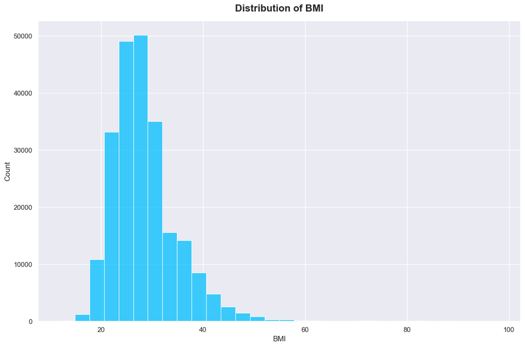

```python
plt.figure(figsize = (12, 8))
sns.histplot(
    data = df,
    x = 'BMI',
    bins = 30,
    color = 'deepskyblue',
    edgecolor = 'white',
    linewidth = 0.8,
);

plt.title('Distribution of BMI', fontsize = 16, fontweight = 'bold', pad = 15)
plt.xlabel('BMI', fontsize = 12)
plt.ylabel('Count', fontsize = 12)
plt.tight_layout()
plt.show()

# REFERENCES
# https://seaborn.pydata.org/generated/seaborn.histplot.html
```

```python
df['BMI'].describe()
```

```
count    229474.000000
mean         28.687508
std           6.789204
min          12.000000
25%          24.000000
50%          27.000000
75%          32.000000
max          98.000000
Name: BMI, dtype: float64
```

**Distribution of BMI Histogram**: The histogram shows the distribution of the BMI variable. We can see that the data distribution is right-skewed, with most values falling between 20 and 30 and a tail leading to the right towards the higher-end values. Given the max value of 98, the values around this data point are not visible on the plot and appear to be outliers as they sit nowhere near the concentration of data. A normal BMI falls between 18.5 and 24.9, yet the majority of the data sits above that range, meaning the majoring of the participants are overweight or heavier. This is important to note as higher BMI is a known risk factor for diabetes.

Reference: https://www.heart.org/en/healthy-living/healthy-eating/losing-weight/bmi-in-adult

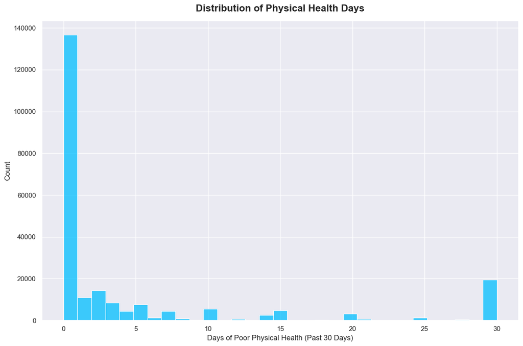

```python
plt.figure(figsize = (12, 8))
sns.histplot(
    data = df,
    x = 'PhysicalHealthDays',
    bins = 31,
    color = 'deepskyblue',
    edgecolor = 'white',
    linewidth = 0.8,
);

plt.title('Distribution of Physical Health Days', fontsize = 16, fontweight = 'bold', pad = 15)
plt.xlabel('Days of Poor Physical Health (Past 30 Days)', fontsize = 12)
plt.ylabel('Count', fontsize = 12)
plt.tight_layout()
plt.show()
```

```python
df['PhysicalHealthDays'].describe()
```

```
count    229474.000000
mean          4.681219
std           9.050877
min           0.000000
25%           0.000000
50%           0.000000
75%           4.000000
max          30.000000
Name: PhysicalHealthDays, dtype: float64
```

**Distribution of Physical Health Days Histogram**: The histogram shows us that this variable is heavily right-skewed, with the majority of the data falling on 0. This is why the median value is 0 despite the mean value being roughly 4.7 (the group of higher-end values pulls the mean up). The most notable feature looking at the plot above is the second spike at 30 days, telling us that a subgroup of observations reported poor physical health days for every day of that month. This is important to note as we saw above that diabetics traditionally average more bad physical health days than non-diabetics, so this could be a useful signal to help distinguish between the two.

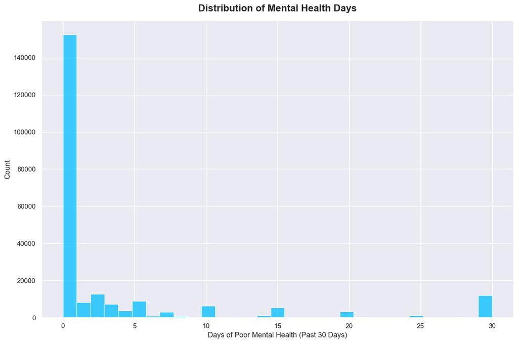

```python
plt.figure(figsize = (12, 8))
sns.histplot(
    data = df,
    x = 'MentalHealthDays',
    bins = 31,
    color = 'deepskyblue',
    edgecolor = 'white',
    linewidth = 0.8,
);

plt.title('Distribution of Mental Health Days', fontsize = 16, fontweight = 'bold', pad = 15)
plt.xlabel('Days of Poor Mental Health (Past 30 Days)', fontsize = 12)
plt.ylabel('Count', fontsize = 12)
plt.tight_layout()
plt.show()
```

```python
df['MentalHealthDays'].describe()
```

```
count    229474.000000
mean          3.509866
std           7.717643
min           0.000000
25%           0.000000
50%           0.000000
75%           2.000000
max          30.000000
Name: MentalHealthDays, dtype: float64
```

**Distribution of Mental Health Days Histogram**: Looking at the histogram above, we can once again see a heavily right-skewed data distribution, with most of the observations falling at 0. The mean for this variable is 3.51, which is slightly lower than the previous observation, but still follows the same pattern of being higher than the median, which is once again 0. This is once again because the right tail of higher-end values pulls the average value up. As with the previous plot, there is a second spike at 30 days, telling us that a subgroup of observations reported poor mental health days every day of the month. This is important to note as we saw above that diabetics traditionally average more bad mental health days than non-diabetics (not as severe as physical health days but still note worthy), so this could be a useful signal to help distinguish between the two.

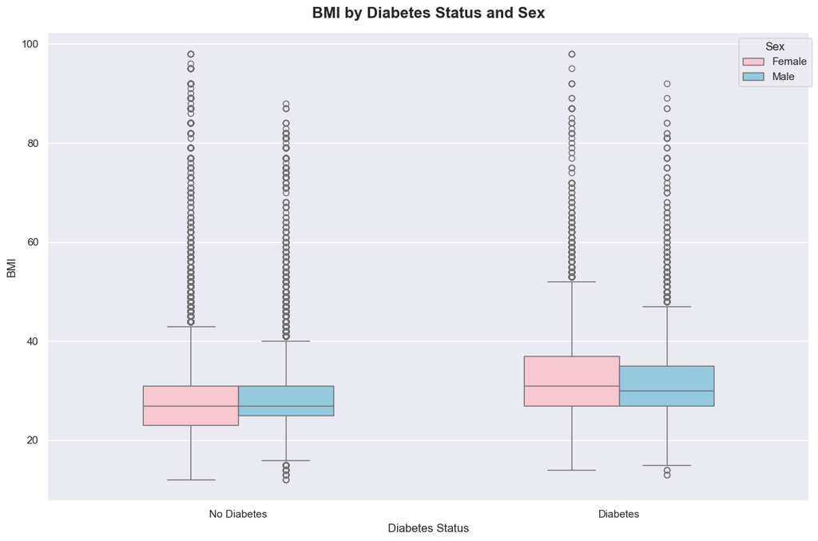

```python
plt.figure(figsize = (12, 8))
sns.boxplot(
    data = df,
    x = 'Diabetes',
    y = 'BMI',
    width = 0.5,
    hue = 'SexLabel',
    palette = {
        'Female' : 'pink',
        'Male'   : 'skyblue'
    }
);

plt.title('BMI by Diabetes Status and Sex', fontsize = 16, fontweight = 'bold', pad = 15)
plt.xlabel('Diabetes Status', fontsize = 12)
plt.ylabel('BMI', fontsize = 12)
plt.xticks([0, 1], ['No Diabetes', 'Diabetes'])
plt.legend(title = 'Sex', bbox_to_anchor = (1.01, 1))
plt.tight_layout()
plt.show()

# REFERENCES
# https://seaborn.pydata.org/generated/seaborn.boxplot.html
```

```python
df.groupby('SexLabel')['BMI'].describe()
# https://www.statology.org/pandas-groupby-describe/
# Wanted to combine the describe function and groupby function stated in previous labs and lectures for accurate information of the box plot.
```

| SexLabel | count | mean | std | min | 25% | 50% | 75% | max |
| --- | --- | --- | --- | --- | --- | --- | --- | --- |
| Female | 128715.0 | 28.501884 | 7.263039 | 12.0 | 24.0 | 27.0 | 32.0 | 98.0 |
| Male | 100759.0 | 28.924631 | 6.122715 | 12.0 | 25.0 | 28.0 | 32.0 | 92.0 |

```python
# got idea from above and code in previous assignments
# df.groupby(['Age_category','Gender'],observed=False).size().reset_index(name='Count')
#giving the index a name of count
df.groupby(['SexLabel', 'Diabetes'])['BMI'].describe()
```

| SexLabel | Diabetes | count | mean | std | min | 25% | 50% | 75% | max |
| --- | --- | --- | --- | --- | --- | --- | --- | --- | --- |
| Female | 0 | 110370.0 | 27.834538 | 6.920495 | 12.0 | 23.0 | 27.0 | 31.0 | 98.0 |
|  | 1 | 18345.0 | 32.516872 | 7.948945 | 14.0 | 27.0 | 31.0 | 37.0 | 98.0 |
| Male | 0 | 84007.0 | 28.439178 | 5.892922 | 12.0 | 25.0 | 27.0 | 31.0 | 88.0 |
|  | 1 | 16752.0 | 31.359062 | 6.650423 | 13.0 | 27.0 | 30.0 | 35.0 | 92.0 |

**BMI by Diabetes Status and Sex Box Plot**: Both males and females in the diabetic group have a higher BMI than the non-diabetic group. The median BMI rises from 27 in the non-diabetic groups to 31 for females and 30 for males with diabetes. In addition to this, the entire box shifts up with these values. The diabetic groups also have a wider IQR, especially for females with diabetes. The gap between males and females within the same status is small, so diabetes separates the BMI distribution much more than sex does. This is important to note as the upward BMI shift in the diabetic groups is direct evidence that BMI is linked to diabetes.

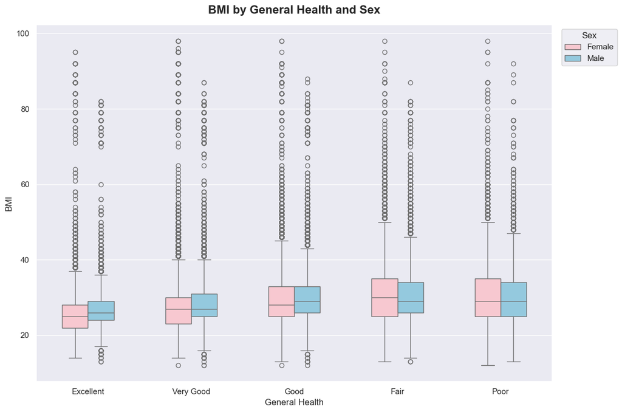

```python
plt.figure(figsize = (12, 8))
sns.boxplot(
    data = df,
    x = 'GeneralHealthGroup',
    y = 'BMI',
    width = 0.5,
    hue = 'SexLabel',
    palette = {
        'Female' : 'pink',
        'Male'   : 'skyblue'
    },
);

plt.title('BMI by General Health and Sex', fontsize = 16, fontweight = 'bold', pad = 15)
plt.xlabel('General Health', fontsize = 12)
plt.ylabel('BMI', fontsize = 12)
plt.legend(title = 'Sex', bbox_to_anchor = (1.01, 1))
plt.tight_layout()
plt.show()
```

```python
df.groupby(['SexLabel', 'GeneralHealthGroup'])['BMI'].describe()
```

| SexLabel | GeneralHealthGroup | count | mean | std | min | 25% | 50% | 75% | max |
| --- | --- | --- | --- | --- | --- | --- | --- | --- | --- |
| Female | Excellent | 19342.0 | 25.519026 | 5.824930 | 14.0 | 22.0 | 25.0 | 28.0 | 95.0 |
|  | Very Good | 43576.0 | 27.506197 | 6.344829 | 12.0 | 23.0 | 27.0 | 30.0 | 98.0 |
|  | Good | 40503.0 | 29.503222 | 7.247744 | 12.0 | 25.0 | 28.0 | 33.0 | 98.0 |
|  | Fair | 18304.0 | 30.907507 | 8.320685 | 13.0 | 25.0 | 30.0 | 35.0 | 98.0 |
|  | Poor | 6990.0 | 30.861374 | 9.140817 | 12.0 | 25.0 | 29.0 | 35.0 | 98.0 |
| Male | Excellent | 15512.0 | 27.033974 | 5.057602 | 13.0 | 24.0 | 26.0 | 29.0 | 82.0 |
|  | Very Good | 33789.0 | 28.338690 | 5.582045 | 12.0 | 25.0 | 27.0 | 31.0 | 87.0 |
|  | Good | 33129.0 | 29.633614 | 6.082993 | 12.0 | 26.0 | 29.0 | 33.0 | 88.0 |
|  | Fair | 13241.0 | 30.382374 | 7.116621 | 13.0 | 26.0 | 29.0 | 34.0 | 87.0 |
|  | Poor | 5088.0 | 30.170008 | 7.825173 | 13.0 | 25.0 | 29.0 | 34.0 | 92.0 |

**BMI General Health and Sex Box Plot**: BMI tends to rise as general health declines. Median BMI climbs from 25 (females) and 26 (males) when health is excellent to 30 (females) and 29 (males) when health is fair. Within each health group, the male and female distributions are close, so general health separates BMI more than sex does. This is important to note as general health and BMI both move in the same direction as diabetes risk, suggesting that they contain information we will want to account for when modeling our data.

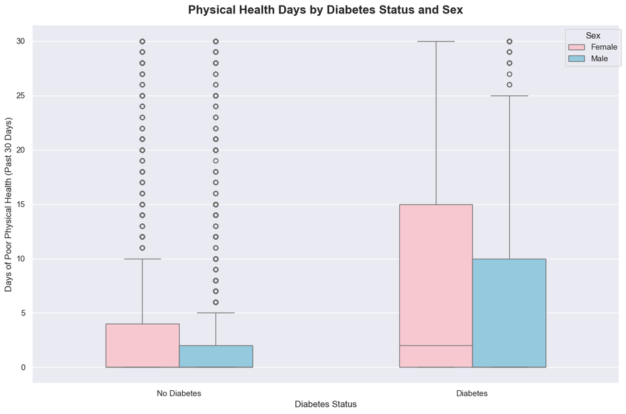

```python
plt.figure(figsize = (12, 8))
sns.boxplot(
    data = df,
    x = 'Diabetes',
    y = 'PhysicalHealthDays',
    width = 0.5,
    hue = 'SexLabel',
    palette = {
        'Female' : 'pink',
        'Male'   : 'skyblue'
    },
);

plt.title('Physical Health Days by Diabetes Status and Sex', fontsize = 16, fontweight = 'bold', pad = 15)
plt.xlabel('Diabetes Status', fontsize = 12)
plt.ylabel('Days of Poor Physical Health (Past 30 Days)', fontsize = 12)
plt.xticks([0, 1], ['No Diabetes', 'Diabetes'])
plt.legend(title = 'Sex', bbox_to_anchor = (1.01, 1))
plt.tight_layout()
plt.show()
```

```python
df.groupby(['SexLabel', 'Diabetes'])['PhysicalHealthDays'].describe()
```

| SexLabel | Diabetes | count | mean | std | min | 25% | 50% | 75% | max |
| --- | --- | --- | --- | --- | --- | --- | --- | --- | --- |
| Female | 0 | 110370.0 | 4.420395 | 8.638723 | 0.0 | 0.0 | 0.0 | 4.0 | 30.0 |
|  | 1 | 18345.0 | 8.746961 | 11.451388 | 0.0 | 0.0 | 2.0 | 15.0 | 30.0 |
| Male | 0 | 84007.0 | 3.633804 | 8.146765 | 0.0 | 0.0 | 0.0 | 2.0 | 30.0 |
|  | 1 | 16752.0 | 7.199797 | 11.119966 | 0.0 | 0.0 | 0.0 | 10.0 | 30.0 |

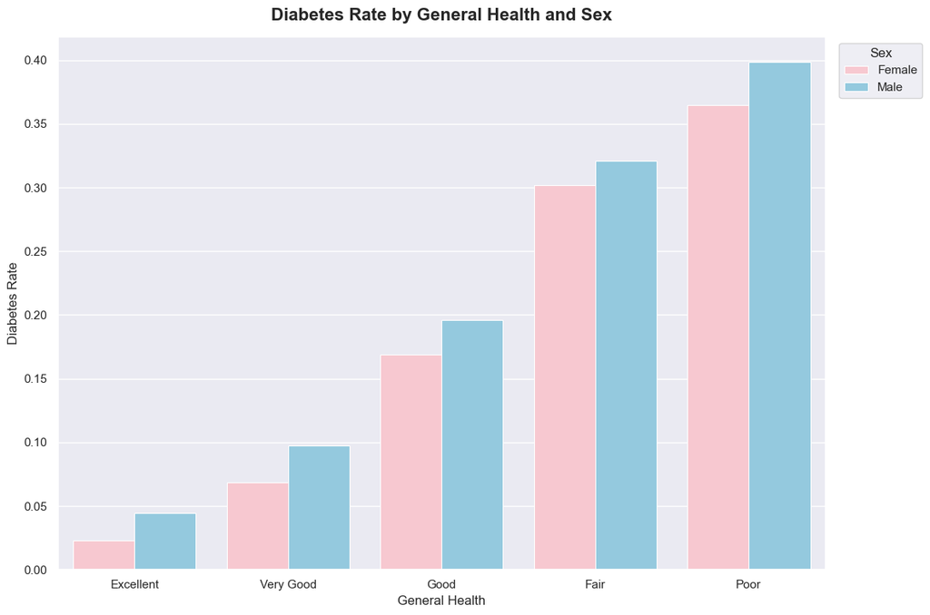

```python
diabetes_rate_per_health_group = (
    df
    .groupby(['GeneralHealthGroup', 'SexLabel'])
    .agg(
        diabetes_rate = ('Diabetes', 'mean')
    )
    .reset_index()
)

plt.figure(figsize = (12, 8))
sns.barplot(
    data = diabetes_rate_per_health_group,
    x = 'GeneralHealthGroup',
    y = 'diabetes_rate',
    hue = 'SexLabel',
    palette = {
        'Female': 'pink',
        'Male': 'skyblue'
    },
    edgecolor = 'white',
    linewidth = 0.8
);

plt.title('Diabetes Rate by General Health and Sex', fontsize = 16, fontweight = 'bold', pad = 15)
plt.xlabel('General Health', fontsize = 12)
plt.ylabel('Diabetes Rate', fontsize = 12)
plt.legend(title = 'Sex', bbox_to_anchor = (1.01, 1))
plt.tight_layout()
plt.show()

# REFERENCES
# https://seaborn.pydata.org/generated/seaborn.barplot.html
```

```python
df.groupby(['GeneralHealthGroup', 'SexLabel'],observed=False)['Diabetes'].mean()
```

```
GeneralHealthGroup  SexLabel
Excellent           Female      0.023162
                    Male        0.044288
Very Good           Female      0.068455
                    Male        0.097576
Good                Female      0.168802
                    Male        0.195810
Fair                Female      0.301956
                    Male        0.321275
Poor                Female      0.364807
                    Male        0.398388
Name: Diabetes, dtype: float64
```

**Diabetes Rate by General Health and Sex Bar Plot**: There is a strong, steady trend between general health and diabetes rate. Ad general health worsens from Excellent to Poor, the rate of diabetes raises sharply, from about 2-4% in the Excellent group to roughly 36-40% in the Poor group, more than a 10x increase. Within each health group, males have a slightly higher diabetes rate than females (roughly 2-3% higher for each group), but the gap between sexes is much smaller compared to the gap across each health group, telling us that the general health signal is much more important. This is important to note as general health has shown itself as having one of the clearest relationships with the diabetes variable out of every one we have looked at, making it a top predictor to use for our models.

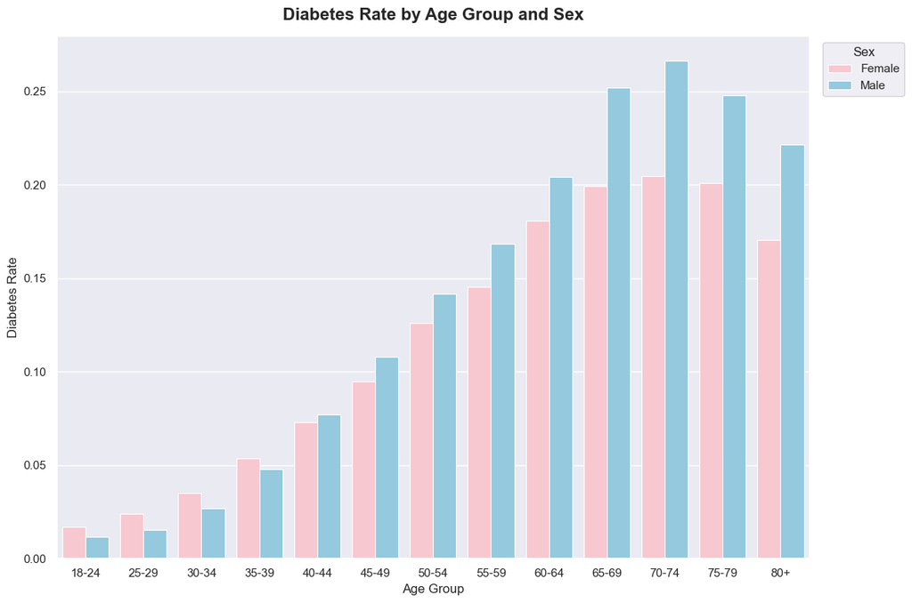

```python
diabetes_rate_per_age_group = (
    df
    .groupby(['AgeGroup', 'SexLabel'])
    .agg(
        diabetes_rate = ('Diabetes', 'mean')
    )
    .reset_index()
)

plt.figure(figsize = (12, 8))
sns.barplot(
    data = diabetes_rate_per_age_group,
    x = 'AgeGroup',
    y = 'diabetes_rate',
    hue = 'SexLabel',
    palette = {
        'Female': 'pink',
        'Male': 'skyblue'
    },
    edgecolor = 'white',
    linewidth = 0.8
);

plt.title('Diabetes Rate by Age Group and Sex', fontsize = 16, fontweight = 'bold', pad = 15)
plt.xlabel('Age Group', fontsize = 12)
plt.ylabel('Diabetes Rate', fontsize = 12)
plt.legend(title = 'Sex', bbox_to_anchor = (1.01, 1))
plt.tight_layout()
plt.show()
```

```python
df.groupby(['AgeGroup', 'SexLabel'],observed=False)['Diabetes'].mean()
```

```
AgeGroup  SexLabel
18-24     Female      0.016879
          Male        0.011599
25-29     Female      0.023938
          Male        0.015242
30-34     Female      0.035039
          Male        0.026903
35-39     Female      0.053752
          Male        0.047786
40-44     Female      0.072967
          Male        0.076961
45-49     Female      0.094877
          Male        0.107938
50-54     Female      0.126087
          Male        0.141573
55-59     Female      0.145565
          Male        0.168515
60-64     Female      0.180911
          Male        0.204287
65-69     Female      0.199381
          Male        0.252105
70-74     Female      0.204575
          Male        0.266263
75-79     Female      0.200921
          Male        0.247724
80+       Female      0.170655
          Male        0.221380
Name: Diabetes, dtype: float64
```

**Diabetes Rate by Age Group and Sex Bar Plot**: Diabetes rate steadily rises with age, climbing from under 2% in the 18-24 group up to a peak around 70-74 (20% for females and 26.7% for males), then dipping slightly down to roughly 17% for females and 22% for males. In younger age groups, females tend to have a slightly higher rate of diabetes, however after age group 40-44, males have a higher rate of diabetes and it only becomes more clear as the age group continues to go up. This is important to note because age shows a strong, consistent relationship with the diabetes variable, making it another key predictor to use when it comes time to modeling, and the sex difference in older age groups suggests that age and sex may be correlated in some way.

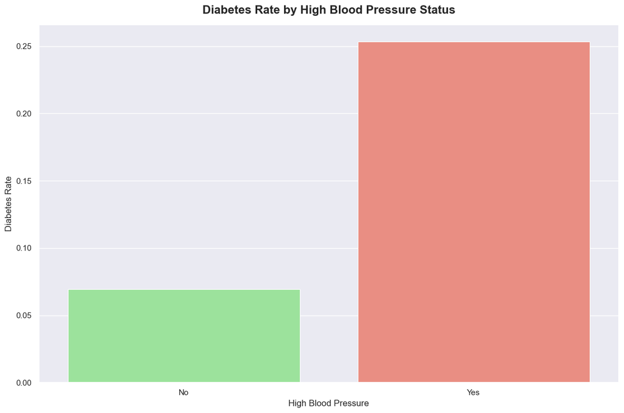

```python
hbp_diabetes_rate = (
    df
    .groupby('HighBloodPressure')
    .agg(
        diabetes_rate = ('Diabetes', 'mean')
    )
    .reset_index()
)

plt.figure(figsize = (12, 8))
sns.barplot(
    data = hbp_diabetes_rate,
    x = 'HighBloodPressure',
    y = 'diabetes_rate',
    hue = 'HighBloodPressure',
    palette = {0 : 'lightgreen', 1 : 'salmon'},
    edgecolor = 'white',
    linewidth = 0.8,
    legend = False
);

plt.title('Diabetes Rate by High Blood Pressure Status', fontsize = 16, fontweight = 'bold', pad = 15)
plt.xlabel('High Blood Pressure', fontsize = 12)
plt.ylabel('Diabetes Rate', fontsize = 12)
plt.xticks([0, 1], ['No', 'Yes'])
plt.tight_layout()
plt.show()
```

```python
df.groupby('HighBloodPressure')['Diabetes'].mean()
```

```
HighBloodPressure
0    0.069417
1    0.253261
Name: Diabetes, dtype: float64
```

**Diabetes Rate by High Blood Pressure Status Bar Plot**: People with high blood pressure have a much higher diabetes rate (about 25%) than those who do not have high blood pressure (about 7%), roughly 3.5 times higher.

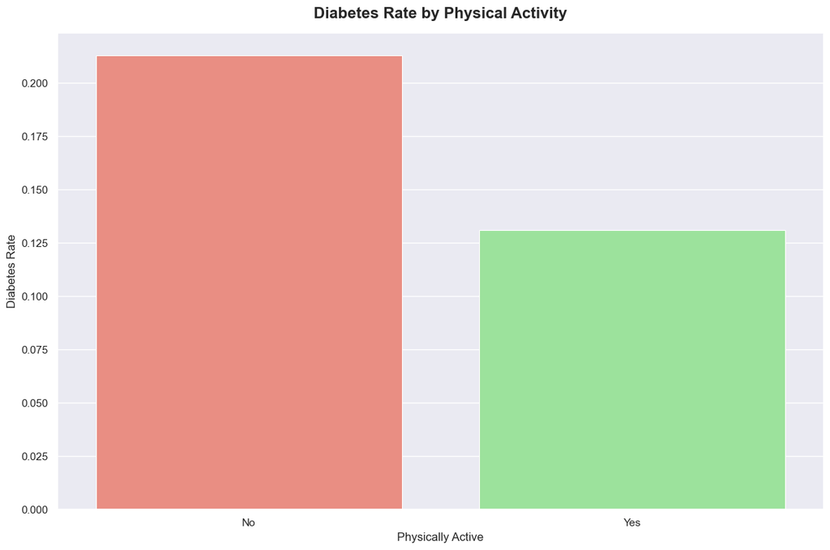

```python
physical_activity_diabetes_rate = (
    df
    .groupby('PhysicalActivity')
    .agg(
        diabetes_rate = ('Diabetes', 'mean')
    )
    .reset_index()
)

plt.figure(figsize = (12, 8))
sns.barplot(
    data = physical_activity_diabetes_rate,
    x = 'PhysicalActivity',
    y = 'diabetes_rate',
    hue = 'PhysicalActivity',
    palette = {0 : 'salmon', 1 : 'lightgreen'},
    edgecolor = 'white',
    linewidth = 0.8,
    legend = False,
);

plt.title('Diabetes Rate by Physical Activity', fontsize = 16, fontweight = 'bold', pad = 15)
plt.xlabel('Physically Active', fontsize = 12)
plt.ylabel('Diabetes Rate', fontsize = 12)
plt.xticks([0, 1], ['No', 'Yes'])
plt.tight_layout()
plt.show()
```

```python
df.groupby('PhysicalActivity')['Diabetes'].mean()
```

```
PhysicalActivity
0    0.212831
1    0.131137
Name: Diabetes, dtype: float64
```

**Diabetes Rate by Physical Activity Bar Plot**: People who are not physically active have a higher diabetes rate (about 21%) than those who are physically active (about 13%).

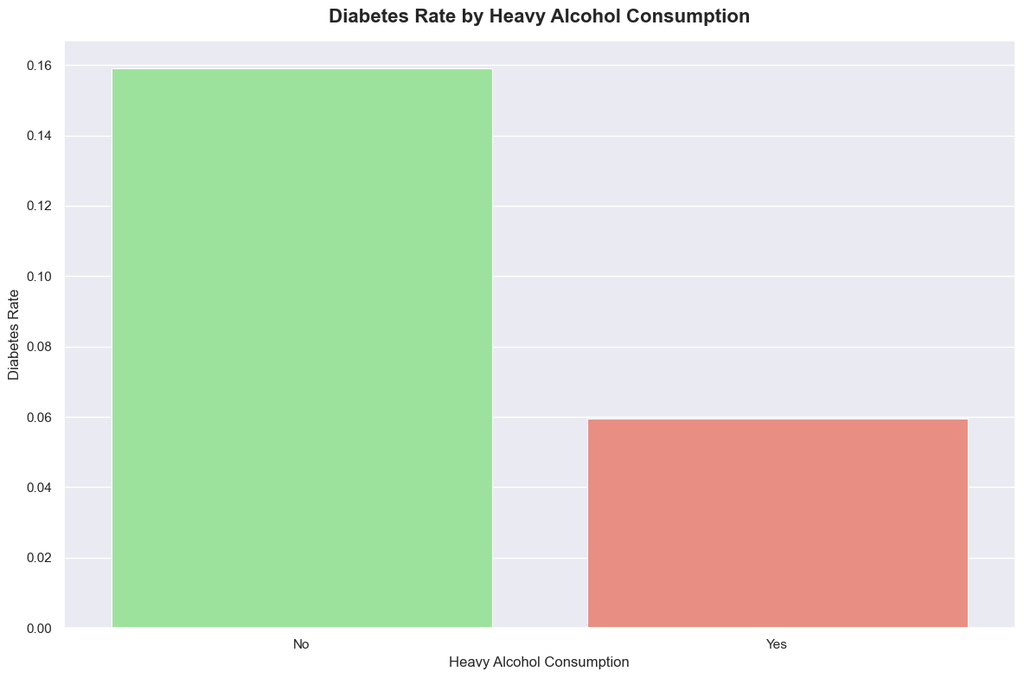

```python
alcohol_diabetes_rate = (
    df
    .groupby('HeavyAlcoholConsumption')
    .agg(
        diabetes_rate = ('Diabetes', 'mean')
    )
    .reset_index()
)

plt.figure(figsize = (12, 8))
sns.barplot(
    data = alcohol_diabetes_rate,
    x = 'HeavyAlcoholConsumption',
    y = 'diabetes_rate',
    hue = 'HeavyAlcoholConsumption',
    palette = {0 : 'lightgreen', 1 : 'salmon'},
    edgecolor = 'white',
    linewidth = 0.8,
    legend = False,
);

plt.title('Diabetes Rate by Heavy Alcohol Consumption', fontsize = 16, fontweight = 'bold', pad = 15)
plt.xlabel('Heavy Alcohol Consumption', fontsize = 12)
plt.ylabel('Diabetes Rate', fontsize = 12)
plt.xticks([0, 1], ['No', 'Yes'])
plt.tight_layout()
plt.show()
```

```python
df.groupby('HeavyAlcoholConsumption')['Diabetes'].mean()
```

```
HeavyAlcoholConsumption
0    0.158985
1    0.059642
Name: Diabetes, dtype: float64
```

**Diabetes Rate by Heavy Alcohol Consumption Bar Plot**: People who report heavy alcohol consumption have a lower diabetes rate (about 6%) than those who do not (about 16%).

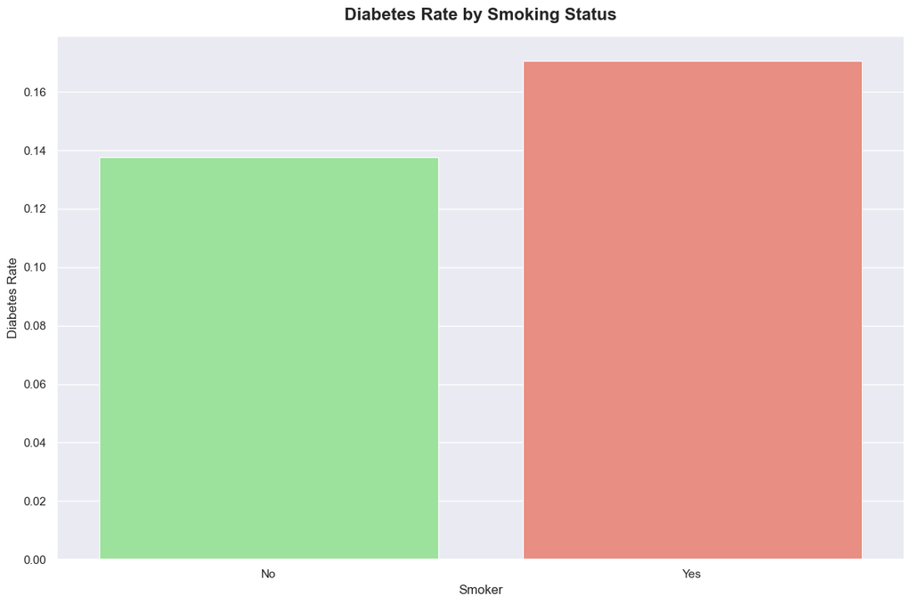

```python
smoker_diabetes_rate = (
    df
    .groupby('Smoker')
    .agg(
        diabetes_rate = ('Diabetes', 'mean')
    )
    .reset_index()
)

plt.figure(figsize = (12, 8))
sns.barplot(
    data = smoker_diabetes_rate,
    x = 'Smoker',
    y = 'diabetes_rate',
    hue = 'Smoker',
    palette = {0 : 'lightgreen', 1 : 'salmon'},
    edgecolor = 'white',
    linewidth = 0.8,
    legend = False,
);

plt.title('Diabetes Rate by Smoking Status', fontsize = 16, fontweight = 'bold', pad = 15)
plt.xlabel('Smoker', fontsize = 12)
plt.ylabel('Diabetes Rate', fontsize = 12)
plt.xticks([0, 1], ['No', 'Yes'])
plt.tight_layout()
plt.show()
```

```python
df.groupby('Smoker')['Diabetes'].mean()
```

```
Smoker
0    0.137651
1    0.170485
Name: Diabetes, dtype: float64
```

**Diabetes Rate by Smoking Status Bar Plot**: Smokers have a higher diabetes rate (about 17%) than people who do not smoke (about 13.7%).

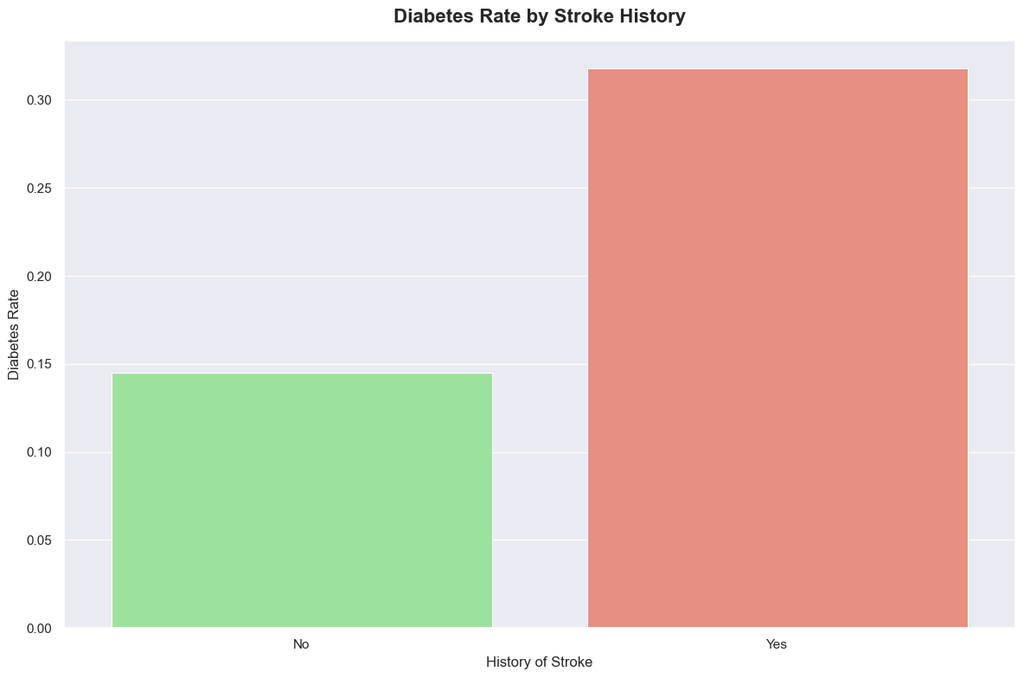

```python
stroke_diabetes_rate = (
    df
    .groupby('Stroke')
    .agg(
        diabetes_rate = ('Diabetes', 'mean')
    )
    .reset_index()
)

plt.figure(figsize = (12, 8))
sns.barplot(
    data = stroke_diabetes_rate,
    x = 'Stroke',
    y = 'diabetes_rate',
    hue = 'Stroke',
    palette = {0 : 'lightgreen', 1 : 'salmon'},
    edgecolor = 'white',
    linewidth = 0.8,
    legend = False,
);

plt.title('Diabetes Rate by Stroke History', fontsize = 16, fontweight = 'bold', pad = 15)
plt.xlabel('History of Stroke', fontsize = 12)
plt.ylabel('Diabetes Rate', fontsize = 12)
plt.xticks([0, 1], ['No', 'Yes'])
plt.tight_layout()
plt.show()
```

```python
df.groupby('Stroke')['Diabetes'].mean()
```

```
Stroke
0    0.145212
1    0.317775
Name: Diabetes, dtype: float64
```

**Diabetes Rate by Stroke History Bar Plot**: People with a history of stroke have a higher diabetes rate (about 31.8%) than those who do not (about 14.5%).

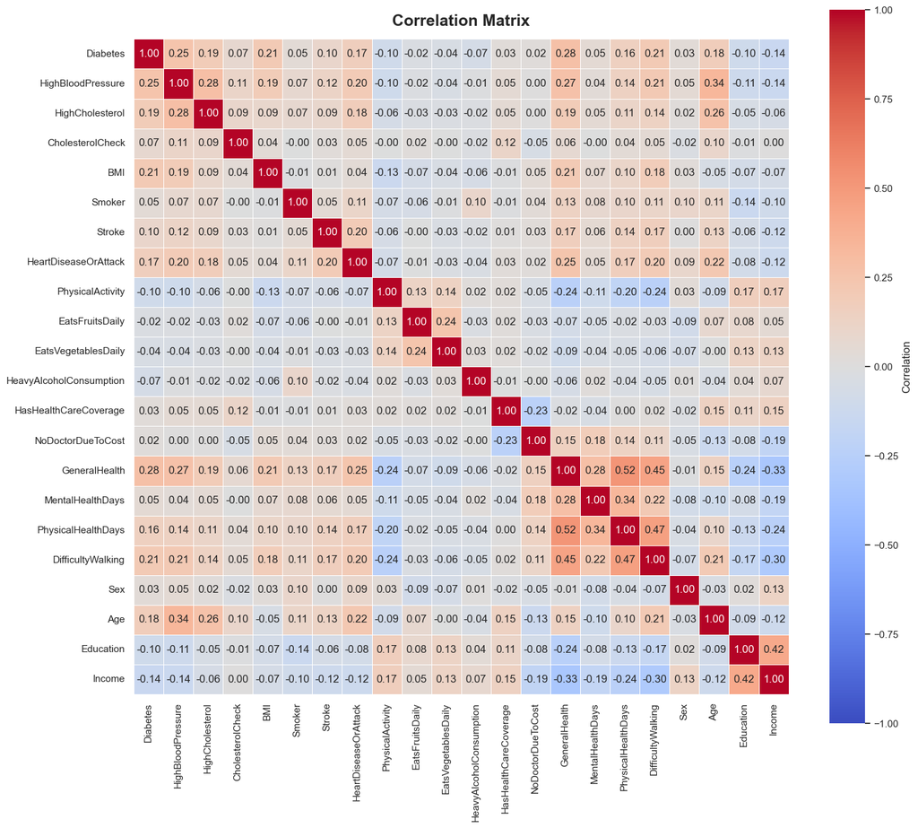

```python
corr_matrix = df.iloc[:, 0:-8].corr()

plt.figure(figsize = (15, 15))
sns.heatmap(
    data = corr_matrix,
    annot = True,
    center = 0,
    vmin = -1,
    vmax = 1,
    fmt = '.2f',
    linewidths = 0.5,
    square = True,
    cbar_kws = {
        'shrink': 0.8,
        'label': 'Correlation'
    },
    cmap = 'coolwarm' # try coolwarm, rocket, mako, flare, crest
);

plt.title('Correlation Matrix', fontsize = 18, fontweight = 'bold', pad = 15)
plt.tight_layout()
plt.show()

# REFERENCE
# https://seaborn.pydata.org/generated/seaborn.heatmap.html
```

**Correlation Matrix Heatmap**: This heatmap shows the pairwise correlations between all numeric variables in the dataset, with the diagonal representing each variable correlated with itself. Focusing on the Diabetes row, the strongest positive correlations are with GeneralHealth (0.28), HighBloodPressure (0.25), BMI (0.21), DifficultyWalking (0.21), HighCholesterol (0.19), and Age (0.18). Since GeneralHealth is coded so that higher numbers mean worse general health quality, this positive correlation means that worse general health quality is associated with diabetes. We can see that Diabetes is negatively correlated with PhysicalActivity (-0.1), Education (-0.1), and Income (-0.14), suggesting that diabetes is potentially more common among lower-income, less-active, and lower-education groups. None of the variables are necessarily strongly correlated with Diabetes themselves and suggests that no single variable can predict whether or not a person has diabetes by itself. The strongest off-diagonal correlation in the whole matrix is between GeneralHealth and PhysicalHealthDays (0.52), which makes sense given the context of having poor general health is going to lead to more bad physical health days.